# 02 – Basics

Sebastian Raschka

# R Resources and Help

- Have a look at the official introduction to R, which is freely available at https://cran.r-project.org/doc/manuals/r-release/R-intro.html – it is a much more thorough version compared to my series of notes.

# Executing code

- Personally, I prefer using R Studio when working with R (for details, see 01-installing-r.md)
- In R Studio, you can set up a R Markdown document where you can write notes and execute code at the same time – it’s similar to a MS Word document that also allows you to run code; in addition, there is also a console view to execute code in the conventional way:

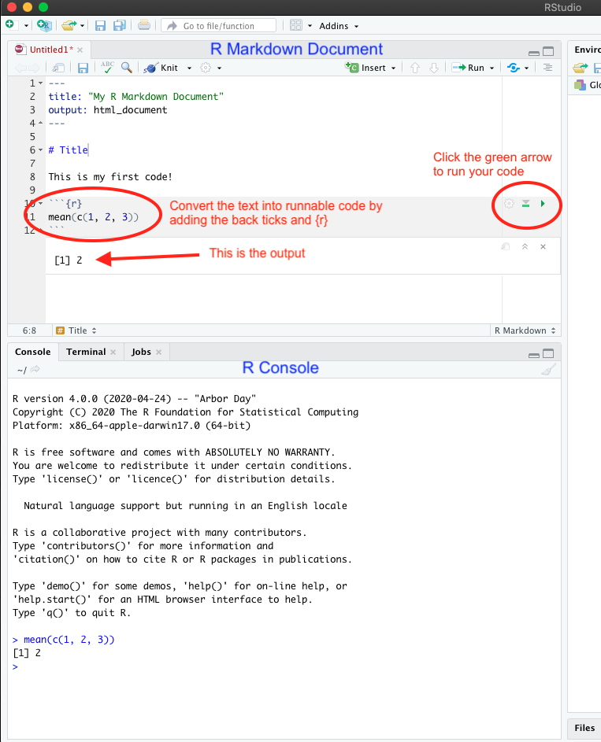

- One thing to notice about R, coming from Python or other programming languages, is the somewhat unusual assignment operator `<-`. We use the assignment operator to assign an expression (right side of the assignment operator) to a variable (left side of the assignnment operator). For example

```r
my_variable <- 3+5
```

- Note that assignments per se don’t result in any “visible” outputs. For example, one way to show the result of executing the expression above, `3+5`, you can call the variable that it was assigned to.

```r
my_variable
```

```
## [1] 8
```

- (In computer science contexts, “showing” some result is often called “printing” due to the history of computers – back in the day, before computer monitors were invented, results had to be printed on paper.)

# Reading files

- If your CSV file is in your working directory (you can display your working directory path by executing `getcwd()`), you can load it via

  read.csv(‘myfile.csv’)
- However, if the CSV file you want to read is not in your current working directory, this command will fail. If this is personal code that you are not intendin on sharing with anyone else, it doesn’t hurt to provide the full path; for example,

  read.csv(‘/Users/sebastian/Data/myfile.csv’)
- For your convenience, you could also just change your working directory path. Both the default R app and R Studio app have options for that:

[figure not shown]

# Data Types

- Similar to Python, everything in R is an object.

## Floats (real numbers)

- You may be used to referring to real numbers as floats (or doubles) in other programming languages; in R, real numbers are represented via the `numeric` data type

## Sequences

```r
1:10
```

```
##  [1]  1  2  3  4  5  6  7  8  9 10
```

## Strings / Character Vectors

# Functions

- Note that in contrast to Python, R doesn’t require an explicit `return` call – if `return` is not used, the R function will return the output of its last expression. For instance, the following two code snippets

```r
mean_squared_error <- function(x, y){
  mean_diff <- mean(x - y)
  mean_diff^2
}

mean_squared_error(c(1, 2, 3), c(1, 2, 5))
```

```
## [1] 0.4444444
```

and

```r
mean_squared_error <- function(x, y){
  mean_diff <- mean(x - y)
  return(mean_diff^2)
}

mean_squared_error(c(1, 2, 3), c(1, 2, 5))
```

```
## [1] 0.4444444
```

both return `0.4444444`

- For your convenience, you can save functions in a separate file and load it into your current R session. E.g., you can save the `mean_squared_error` we created above as a .R file, for example, `mse.R`. Then, you can source the file in your current R session to load the function, a shown in the screenshot below:

[figure not shown]

# Developing R Packages

- If you are interested in developing your own R packages (also known as “extensions”), have a look at the official guide available at https://cran.r-project.org/doc/manuals/r-release/R-exts.html.